# Algoritmo de Metrópolis–Hastings

**Estadística Bayesiana** | UAEMex Valle de México  
Ximena Quintanar Leal · 2025

> *"La verosimilitud actúa como potencial de selección: parámetros que explican mejor los datos reciben más masa."*  
> — César Galindo, §11.9

## 1. Planteamiento

Queremos muestrear de una distribución objetivo $\pi$ conocida **solo hasta una constante de normalización**:

$$\pi(d\theta) = \frac{\tilde{\pi}(\theta)}{Z} \lambda(d\theta), \qquad Z = \int \tilde{\pi}(\theta)\,\lambda(d\theta) \text{ desconocida}$$

La idea de Metrópolis–Hastings: construir una cadena de Markov con distribución invariante $\pi$, usando solo cocientes $\tilde{\pi}(y)/\tilde{\pi}(x)$ — así $Z$ **se cancela**.

### Kernel de transición

Dado el estado actual $x$, se propone $y \sim q(x, \cdot)$ y se acepta con probabilidad:

$$\alpha(x,y) = 1 \wedge \frac{\tilde{\pi}(y)\,q(y,x)}{\tilde{\pi}(x)\,q(x,y)}$$

Con propuesta **simétrica** ($q(x,y) = q(y,x)$):

$$\alpha(x,y) = 1 \wedge \frac{\tilde{\pi}(y)}{\tilde{\pi}(x)}$$

## 2. Implementación general

```python
import numpy as np
import matplotlib.pyplot as plt
from scipy.stats import norm, beta as beta_dist

rng = np.random.default_rng(42)

def metropolis_hastings(log_pi, propuesta, x0, n_iter):
    """
    Algoritmo Metrópolis-Hastings genérico.

    Parámetros
    ----------
    log_pi   : función que regresa log π̃(x) (densidad no normalizada)
    propuesta: función que dado x regresa una propuesta y
    x0       : estado inicial
    n_iter   : número de iteraciones

    Regresa
    -------
    cadena   : array de estados
    tasa_acep: tasa de aceptación empírica
    """
    cadena = np.zeros(n_iter)
    cadena[0] = x0
    aceptados = 0

    for t in range(1, n_iter):
        x_actual = cadena[t-1]
        y = propuesta(x_actual)                       # propuesta
        log_r = log_pi(y) - log_pi(x_actual)          # log razón de Hastings
        if np.log(rng.uniform()) < log_r:             # aceptar con prob min(1, r)
            cadena[t] = y
            aceptados += 1
        else:
            cadena[t] = x_actual                      # rechazar → conservar

    return cadena, aceptados / (n_iter - 1)

print("Función MH definida correctamente.")
```

```
Función MH definida correctamente.
```

## 3. Ejemplo 1: distribución objetivo no estándar

Objetivo: mezcla de dos gaussianas

$$\tilde{\pi}(\theta) = 0.4 \cdot \mathcal{N}(-2, 0.5^2) + 0.6 \cdot \mathcal{N}(3, 1^2)$$

Esta distribución **no tiene forma cerrada** fácil de muestrear directamente.

```
Tasa de aceptación: 0.519  (ideal ~0.23–0.50 para propuesta gaussiana)
```

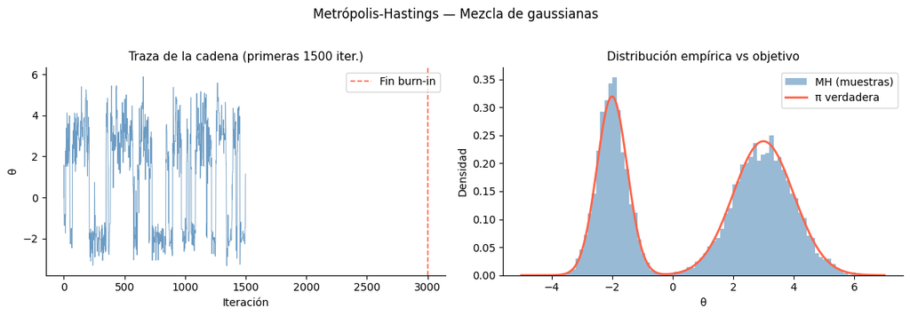

```python
# Densidad objetivo: mezcla de gaussianas
def log_pi_mezcla(x):
    p1 = 0.4 * norm.pdf(x, loc=-2, scale=0.5)
    p2 = 0.6 * norm.pdf(x, loc=3,  scale=1.0)
    return np.log(p1 + p2 + 1e-300)   # +eps para evitar log(0)

# Propuesta: caminata aleatoria gaussiana
sigma_prop = 1.5
propuesta = lambda x: x + rng.normal(0, sigma_prop)

# Correr MH
N = 30_000
cadena, tasa = metropolis_hastings(log_pi_mezcla, propuesta, x0=0.0, n_iter=N)
burn_in = 3000
muestras = cadena[burn_in:]

print(f"Tasa de aceptación: {tasa:.3f}  (ideal ~0.23–0.50 para propuesta gaussiana)")

# Visualización
theta = np.linspace(-5, 7, 500)
pi_true = 0.4*norm.pdf(theta,-2,0.5) + 0.6*norm.pdf(theta,3,1)

fig, axes = plt.subplots(1, 2, figsize=(12, 4))

# Traza
axes[0].plot(cadena[:1500], color='steelblue', linewidth=0.6, alpha=0.8)
axes[0].axvline(burn_in, color='tomato', linestyle='--', linewidth=1.2, label='Fin burn-in')
axes[0].set_title('Traza de la cadena (primeras 1500 iter.)', fontsize=11)
axes[0].set_xlabel('Iteración'); axes[0].set_ylabel('θ')
axes[0].legend(); axes[0].spines['top'].set_visible(False); axes[0].spines['right'].set_visible(False)

# Histograma vs objetivo
axes[1].hist(muestras, bins=80, density=True, color='steelblue', alpha=0.55, label='MH (muestras)')
axes[1].plot(theta, pi_true, color='tomato', linewidth=2, label='π verdadera')
axes[1].set_title('Distribución empírica vs objetivo', fontsize=11)
axes[1].set_xlabel('θ'); axes[1].set_ylabel('Densidad')
axes[1].legend(); axes[1].spines['top'].set_visible(False); axes[1].spines['right'].set_visible(False)

plt.suptitle('Metrópolis-Hastings — Mezcla de gaussianas', fontsize=12, y=1.02)
plt.tight_layout(); plt.show()
```

## 4. Efecto del tamaño de propuesta $\sigma$

El tamaño del paso $\sigma$ de la propuesta controla la exploración:

- $\sigma$ muy pequeño → muchas aceptaciones, exploración lenta (alta autocorrelación)
- $\sigma$ muy grande → pocas aceptaciones, la cadena se queda pegada

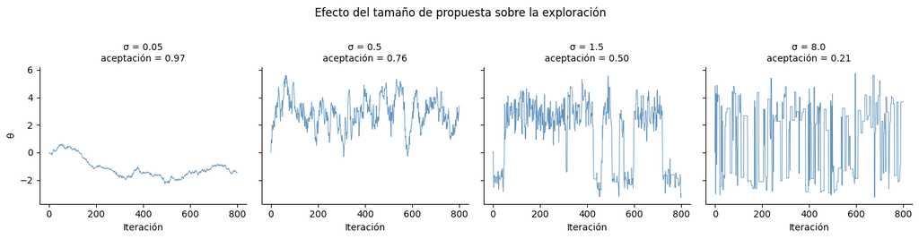

```python
sigmas = [0.05, 0.5, 1.5, 8.0]
fig, axes = plt.subplots(1, len(sigmas), figsize=(14, 3.5), sharey=True)

for ax, s in zip(axes, sigmas):
    prop_s = lambda x, s=s: x + rng.normal(0, s)
    c, tasa_s = metropolis_hastings(log_pi_mezcla, prop_s, x0=0.0, n_iter=8000)
    ax.plot(c[:800], color='steelblue', linewidth=0.7, alpha=0.85)
    ax.set_title(f'σ = {s}\naceptación = {tasa_s:.2f}', fontsize=10)
    ax.set_xlabel('Iteración')
    ax.spines['top'].set_visible(False); ax.spines['right'].set_visible(False)

axes[0].set_ylabel('θ')
plt.suptitle('Efecto del tamaño de propuesta sobre la exploración', fontsize=12, y=1.02)
plt.tight_layout(); plt.show()
```

## 5. Ejemplo 2: inferencia bayesiana — posterior de $\theta$

Modelo: $$X_1,\ldots,X_n \mid \theta \sim \mathcal{N}(\theta, 1), \qquad \theta \sim \mathcal{N}(0, 5^2)$$

La posterior es conocida analíticamente (conjugada), pero la usamos para **validar** MH:

$$\theta \mid X \sim \mathcal{N}\!\left(\frac{n\bar{X}/1}{n/1 + 1/25},\; \frac{1}{n/1 + 1/25}\right)$$

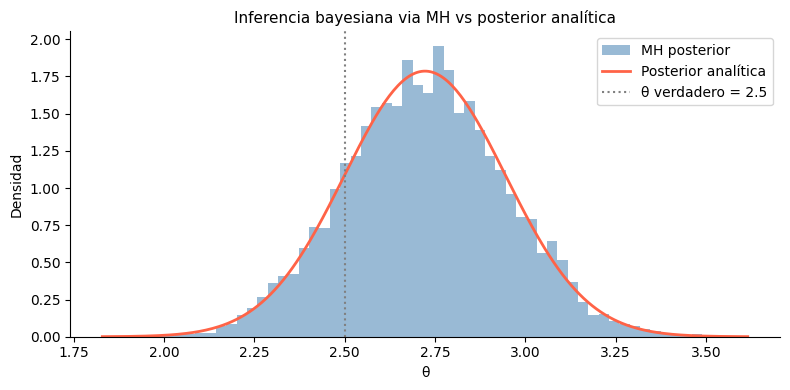

```
Media posterior MH:       2.7225
Media posterior analítica: 2.7223
Tasa de aceptación:        0.535
```

```python
# Datos simulados
theta_verdadero = 2.5
n_obs = 20
datos = rng.normal(theta_verdadero, 1.0, size=n_obs)
x_bar = datos.mean()

# Log-posterior (no normalizada) = log-verosimilitud + log-prior
def log_post(theta):
    ll  = -0.5 * n_obs * (x_bar - theta)**2          # log-verosimilitud (resumida)
    lp  = -0.5 * (theta / 5.0)**2                    # log-prior N(0,25)
    return ll + lp

# MH
cadena_post, tasa_post = metropolis_hastings(log_post, lambda x: x + rng.normal(0, 0.4), x0=0.0, n_iter=20_000)
muestras_post = cadena_post[2000:]

# Posterior analítica
prec_prior, prec_lik = 1/25, n_obs
mu_post  = (x_bar * prec_lik) / (prec_prior + prec_lik)
sig_post = 1.0 / np.sqrt(prec_prior + prec_lik)

theta_grid = np.linspace(mu_post - 4*sig_post, mu_post + 4*sig_post, 300)

fig, ax = plt.subplots(figsize=(8, 4))
ax.hist(muestras_post, bins=60, density=True, color='steelblue', alpha=0.55, label='MH posterior')
ax.plot(theta_grid, norm.pdf(theta_grid, mu_post, sig_post), color='tomato', lw=2, label='Posterior analítica')
ax.axvline(theta_verdadero, color='gray', linestyle=':', lw=1.5, label=f'θ verdadero = {theta_verdadero}')
ax.set_title('Inferencia bayesiana via MH vs posterior analítica', fontsize=11)
ax.set_xlabel('θ'); ax.set_ylabel('Densidad')
ax.legend(); ax.spines['top'].set_visible(False); ax.spines['right'].set_visible(False)
plt.tight_layout(); plt.show()

print(f"Media posterior MH:       {muestras_post.mean():.4f}")
print(f"Media posterior analítica: {mu_post:.4f}")
print(f"Tasa de aceptación:        {tasa_post:.3f}")
```

## 6. Balance detallado — verificación empírica

El teorema de balance detallado garantiza que $\pi$ es la medida invariante:

$$\pi(dx)\,K(x,dy) = \pi(dy)\,K(y,dx)$$

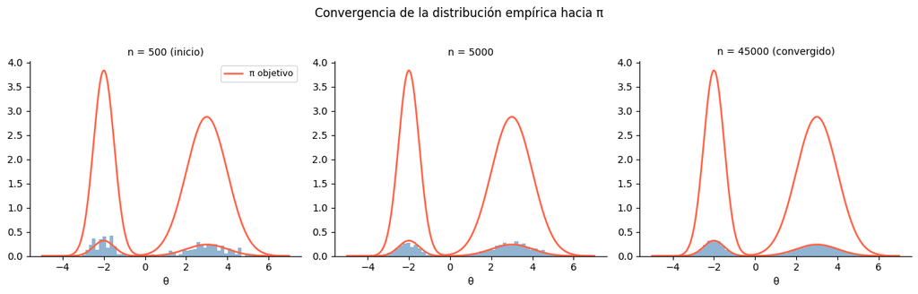

```python
# Verificamos: la distribución de la cadena converge a π
n_test = 50_000
cadena_conv, _ = metropolis_hastings(log_pi_mezcla, lambda x: x+rng.normal(0,1.5), x0=0.0, n_iter=n_test)

# Distribución en distintos momentos de la cadena
fig, axes = plt.subplots(1, 3, figsize=(13, 4), sharey=False)
cortes = [500, 5000, 45000]
nombres = ['n = 500 (inicio)', 'n = 5000', 'n = 45000 (convergido)']

for ax, c, nom in zip(axes, cortes, nombres):
    ax.hist(cadena_conv[:c], bins=50, density=True, color='steelblue', alpha=0.6)
    ax.plot(theta, pi_true/pi_true.sum()*(theta[1]-theta[0])*500/(theta[1]-theta[0]),
            color='tomato', lw=1.8)
    ax.plot(theta, pi_true, color='tomato', lw=1.8, label='π objetivo')
    ax.set_title(nom, fontsize=10)
    ax.set_xlabel('θ')
    ax.spines['top'].set_visible(False); ax.spines['right'].set_visible(False)
    if ax == axes[0]:
        ax.legend(fontsize=9)

plt.suptitle('Convergencia de la distribución empírica hacia π', fontsize=12, y=1.02)
plt.tight_layout(); plt.show()
```

## Referencias

- Galindo, C. *Cambio de medida en probabilidad y análisis estocástico*, §11.9.
- Metropolis, N. et al. (1953). *Equation of State Calculations by Fast Computing Machines*.
- Hastings, W. K. (1970). *Monte Carlo Sampling Methods Using Markov Chains and Their Applications*.